# Ocean Fish Tagging Package

Dougie Beare, Laurie Kell

16 noviembre, 2016

Introduction

Installation

Quick Start

More information

References

# Introduction

`FLTag` is being developed as part of the Atlantic Ocean Tropical Tuna Tagging Programme (AOTTP) coordinated by the International Commission for the Conservation of Atlantic Tunas (ICCAT). AOTTP is funded by the European Union and other ICCAT Contracting Parties.  
`FLTag` is aimed at the statistical analysis and visualisation of large-scale oceanographic fish tagging data with current focus being on bigeye, skipjack and yellowfin tunas. In particular it was developed to calculate the key parameters that can be derived from tagging data, important in population assessements; e.g mortality, growth and migration rates.

Back to Top

# Installation

The simplest way to obtain `FLTag` is to install it from CRAN by using the following command in the R console:

```r
install.packages("FLTag", repos = "http://cloud.r-project.org/")
```

The repos options can be changed depending on personal preferences and includes options such as choosing the directories in which to install the packages see help(install.packages) for more details.

Back to Top

# Quick Start

`FLTag` is part of the `FLR` family of packages, so you can install the latest version of the FLR packages using the FLR installation script:

```r
source("http://flr-project.org/R/instFLR.R")
```

or, if you know you have all the necessary dependencies, directly from the repository:

```r
install.packages(repos="http://flr-project.org/R")
```

To get help please post your questions or suggestions to the FLR mailing list. Conversations can be started at our scrollbak.io room. Bug reports for individual packages can be submitted using their individual github issues page. So that users may have a better idea of what functions are available, which one to choose, or where to seek help, this section provides a general overview of the package. In particular it highlights the various elements, what they do, and provides some examples of usage. More details are given in later sections.

First, load the `FLTag` package:

```r
library(FLTag)
```

There are example datasets for tag releases and recoveries in `FLTag`, which are for used for illustration and as test datasets; alternatively users can load their own tagging data.

```r
data(releases)
data(recoveries)
```

The releases dataset contains details (e.g. location and time) on the releases of tagged tropical tuna species.

```r
head(releases)
```

```
  speciescode rcstagecode ctcode1 ctcode2 latitude longitude gearcode
1         YFT         R-1    7296      NA     15.3     -17.1       BB
2         YFT         R-1    7297      NA     15.3     -17.1       BB
3         YFT         R-1    7298      NA     15.3     -17.1       BB
4         YFT         R-1    7299      NA     15.3     -17.1       BB
5         YFT         R-1    7550      NA     15.3     -17.1       BB
6         YFT         R-1    7551      NA     15.3     -17.1       BB
  depth len specimenid                date
1   338  65        647 2016-07-13 19:52:00
2   338  60        648 2016-07-13 19:52:00
3   338  54        649 2016-07-13 19:52:00
4   338  53        650 2016-07-13 19:52:00
5   338  60        651 2016-07-13 19:52:00
6   338  61        652 2016-07-13 19:52:00
```

Similarly the recoveries data set containts details (e.g. location and time) of when and where those tagged tuna were recovered.

```r
head(recoveries)
```

```
  specimenid rcstagecode ctcode1 ctcode2 latitude longitude gearcode len
1       1527         RCF    5179      NA     15.3     -17.6       BB  51
2        874         RCF   40524      NA     17.8     -16.5       PS  61
3       7700         RCF    8183      NA     18.7     -18.1       BB  51
4       3649         RCF    9998      NA     18.3     -18.7       BB  52
5       8359         RCF   11587      NA     19.0     -18.4       BB  41
6       7476         RCF    7708      NA     17.4     -18.4       BB  51
                 date
1 2016-07-27 12:37:00
2 2016-08-11 11:55:00
3 2016-09-06 09:30:00
4 2016-09-06 09:32:00
5 2016-09-06 09:35:00
6 2016-09-11 09:38:00
```

In tagging databases there are often strange observations and missing values which we can be cleaned out as follows:

```r
recoveries <- recoveries[!is.na(recoveries$latitude),]
recoveries <- recoveries[!is.na(recoveries$longitude),]
releases <- releases[!is.na(releases$latitude),]
releases <- releases[!is.na(releases$longitude),]
releases <- releases[releases$speciescode %in% c('BET','SKJ','YFT'),]
releases <- releases[releases$len >=20,]
```

### Plotting

Plotting when analysing data with `FLTag` is best done using `ggplot2`, see *Grammar of Graphics*[^1]

The `ggplot` functions expects a `data.frame` for its first argument, `data`; then a geometric object `geom` that specifies the actual marks put on to a plot and an aesthetic that is “something you can see” have to be provided. Examples of geometic Objects (geom) include points (geom_point, for scatter plots, dot plots, etc), lines (geom_line, for time series, trend lines, etc) and boxplot (geom_boxplot, for, well, boxplots!). Aesthetic mappings are set with the aes() function and, examples include, position (i.e., on the x and y axes), color (“outside” color), fill (“inside” color), shape (of points), linetype and size. Usually the first thing we should do prior to any data analysis is to plot the data.

In the context of oceanic fish tagging data we can use `FLTag` to plot the location of conventional tag releases using `ggplot2` and also easily add other geographic layers, e.g. for Large Marine Ecosystems and/or the FAD moratorium 2016 which are built-in to `FLTag`:

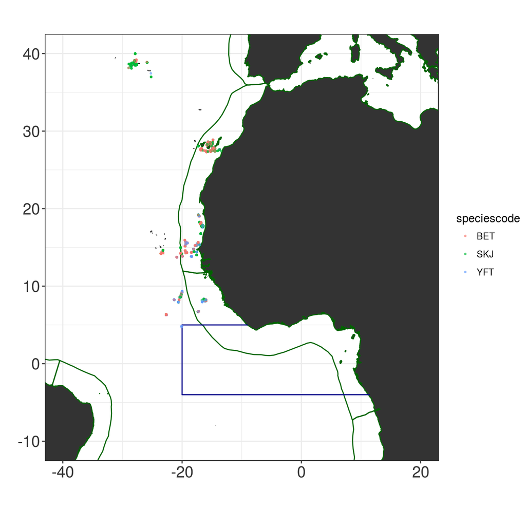

```r
library(ggplot2)
world <- map_data('world')
data("lme")
data("fadmoratorium")

ggplot() + geom_polygon(data=world,aes(x=long,y=lat,group=group))+
  geom_polygon(data=lme,aes(x=long,y=lat,group=group),color='darkgreen',fill=NA,size=0.5)+
  geom_polygon(data=fadmoratorium,aes(x=long,y=lat,group=group),color='darkblue',size=0.5) +
  coord_fixed(1.3,xlim=c(-40,20),ylim=c(-10,40))+
geom_point(aes(x=longitude,y=latitude,color=speciescode),data=releases[releases$speciescode %in% c('BET','SKJ','YFT'),]
             ,alpha=0.5,size=0.5) +
  theme(plot.margin=unit(c(0,0,0,0),"cm"),
        axis.text.x =element_text(colour="grey20",size=15,face="plain"),
        axis.text.y=element_text(colour="grey20",size=15,face="plain"),
        axis.title.y=element_text(size=15))+
  xlab("")+ylab("")
```

Similarly we can plot the spatial distribution of the recovered tuna as follows:

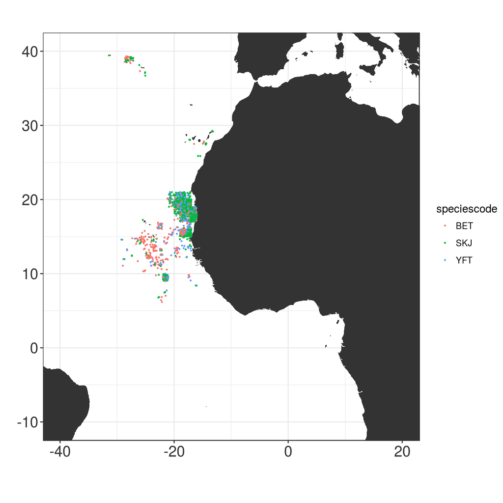

```r
world <- map_data('world')
recoveries$speciescode <- releases$speciescode[match(recoveries$specimenid,releases$specimenid)] # assumes the species identified by the tagger during release was correct
ggplot() + geom_polygon(data=world,aes(x=long,y=lat,group=group))+
  coord_fixed(1.3,xlim=c(-40,20),ylim=c(-10,40))+
geom_point(aes(x=longitude,y=latitude,color=speciescode),data=recoveries[recoveries$speciescode %in% c('BET','SKJ','YFT'),],alpha=1,size=.25)+
  theme(plot.margin=unit(c(0,0,0,0),"cm"),
        axis.text.x =element_text(colour="grey20",size=15,face="plain"),
        axis.text.y=element_text(colour="grey20",size=15,face="plain"),
        axis.title.y=element_text(size=15))+
  xlab("")+ylab("")
```